# 1. Neural networks

## a. Neural networks and logistic regression

Consider a neural network for binary classification using the sigmoid function for each unit. If the network has no hidden layer, explain why the model is equivalent to logistic regression.

If there is no hidden layer, then the logistic function **directly returns the output** given a set of inputs, and the weights serve the same function as a logistic regression model's coefficients. This is indistinguishable from a basic logistic regression model, which outputs a prediction using the sigmoid function given input features $x_i$ and coefficients $\beta_i$ for each feature.

## b. Gradients of two-layer neural network

Consider a simple two-layer network as shown in the lecture slides. Given the cost function used to train the neural networks

$$ \ell(w,\alpha,\beta) = \sum_{i=1}^{m} (y^{(i)} - \sigma(w^\top z^{(i)}))^2 $$

where $\sigma(x)=\frac{1}{1 + e^{-x}}$ is the sigmoid function, show that the gradient is given by

$$ \frac{\partial \ell(w,\alpha,\beta)}{\partial w} = -\sum_{i=1}^{m} 2\left[y^{(i)} - \sigma(u^{(i)})\right]\sigma(u^{(i)})\left[1 - \sigma(u^{(i)})\right]z^{(i)} $$

where $z_1^{(i)} = \sigma(\alpha^\top x^{(i)}), z_2^{(i)} = \sigma(\beta^\top x^{(i)})$. Also find the gradient of $\ell$ with respect to $\alpha$ and $\beta$.

### i. Gradient of $\ell$ with respect to $w$

First, let:

$$\begin{align} w^\top z^{(i)} &= u^{(i)}, \\ \sigma(w^\top z^{(i)}) &= \sigma(u^{(i)}) = \frac{1}{1 + e^{-u^{(i)}}} = (1 + e^{-u^{(i)}})^{-1}, \\ 1 - \sigma(u^{(i)}) &= \frac{1}{1 + e^{u^{(i)}}} \end{align}$$

Then:

$$\begin{align} \frac{\partial \sigma(w^\top z^{(i)})}{\partial w} &= -(1 + e^{-w^\top z^{(i)}})^{-2} (-z^{(i)} e^{-w^\top z^{(i)}}) \\ &= \frac{z^{(i)} e^{-w^\top z^{(i)}}}{(1 + e^{-w^\top z^{(i)}})^2} \\ &= z^{(i)} \frac{1}{1 + e^{-u^{(i)}}} \cdot \frac{e^{-u^{(i)}}}{1 + e^{-u^{(i)}}} \\ &= z^{(i)} \frac{1}{1 + e^{-u^{(i)}}} \cdot \frac{1}{e^{u^{(i)}} (1 + e^{-u^{(i)}})} \\ &= z^{(i)} \frac{1}{1 + e^{-u^{(i)}}} \cdot \frac{1}{1 + e^{u^{(i)}}} \\ &= z^{(i)} \sigma(u^{(i)}) \left[1 - \sigma(u^{(i)})\right] \end{align}$$

Finally, using the derivation above and the chain rule of derivatives (noting the $-$ sign on $\sigma(w^\top z^{(i)})$:

$$\begin{align} \frac{\partial \ell(w,\alpha,\beta)}{\partial w} &= \sum_{i=1}^{m} 2\left[y^{(i)}-\sigma(w^\top z^{(i)})\right] \frac{\partial \left[y^{(i)}-\sigma(w^\top z^{(i)})\right]}{\partial w} \\ &= -\sum_{i=1}^{m} 2\left[y^{(i)}-\sigma(w^\top z^{(i)})\right] z^{(i)} \sigma(u^{(i)}) \left[1 - \sigma(u^{(i)})\right] \\ &= -\sum_{i=1}^{m} 2\left[y^{(i)}-\sigma(w^\top z^{(i)})\right] \sigma(u^{(i)}) \left[1 - \sigma(u^{(i)})\right] z^{(i)} \end{align}$$

## ii. Gradient of $\ell$ with respect to $\alpha$ and $\beta$

First, let:

$$\begin{align} v^{(i)} &= \alpha^\top x^{(i)}, \\ z^{(i)}_1 &= \sigma(v^{(i)}) = \sigma(\alpha^\top x^{(i)}) = \frac{1}{1 + e^{-\alpha^\top x^{(i)}}} \end{align}$$

Then:

$$\begin{align} \frac{\partial z^{(i)}_1}{\partial \alpha} &= \frac{\partial \sigma(v^{(i)})}{\partial \alpha} = \color{blue} { x^{(i)} \sigma(v^{(i)}) \left[1 - \sigma(v^{(i)})\right] } \end{align}$$

This derivation was shown in part i; simply replace $v^{(i)} = \alpha^\top x^{(i)}$ with $u^{(i)} = w^\top z^{(i)}$.

Using a similar substitution:

$$\begin{align} \frac{\partial \ell(w,\alpha,\beta)}{\partial z^{(i)}_1} &= \sum_{i=1}^{m} 2\left[y^{(i)}-\sigma(w^\top z^{(i)})\right] \frac{\partial \left[y^{(i)}-\sigma(w^\top z^{(i)})\right]}{\partial z^{(i)}}, \\ \frac{\partial \left[y^{(i)}-\sigma(w^\top z^{(i)})\right]}{\partial z^{(i)}} &= \color{red} { -w_1 \ \sigma(u^{(i)}) \left[1 - \sigma(u^{(i)})\right] } \end{align}$$

Finally, using the derivations above and the chain rule of derivatives:

$$\begin{align} \frac{\partial \ell(w,\alpha,\beta)}{\partial \alpha} &= \frac{\partial \ell(w,\alpha,\beta)}{\partial z^{(i)}_1} \frac{\partial z^{(i)}_1}{\partial \alpha} \\ &= \color{red}{-}\sum_{i=1}^{m} 2\left[y^{(i)}-\sigma(w^\top z^{(i)})\right] \color{red}{w_1 \ \sigma(u^{(i)}) \left[1 - \sigma(u^{(i)})\right]} \color{blue} {x^{(i)} \sigma(v^{(i)}) \left[1 - \sigma(v^{(i)})\right]} \\ &= -\sum_{i=1}^{m} 2\left[y^{(i)}-\sigma(u^{(i)})\right] \sigma(u^{(i)}) \left[1 - \sigma(u^{(i)})\right] w_1 \ \sigma(v^{(i)}) \left[1 - \sigma(v^{(i)})\right] x^{(i)} \\ \end{align}$$

The gradient of $\ell$ with respect to $\beta$ can be derived using the same method, replacing $v^{(i)} = \alpha^\top x^{(i)}$ with $v^{(i)} = \beta^\top x^{(i)}$ and $w_1$ with $w_2$ (the element of the final layer's weight vector that corresponds to the output of the second unit in the hidden layer):

$$\begin{align} \frac{\partial \ell(w,\alpha,\beta)}{\partial \beta} &= -\sum_{i=1}^{m} 2\left[y^{(i)}-\sigma(u^{(i)})\right] \sigma(u^{(i)}) \left[1 - \sigma(u^{(i)})\right] w_2 \ \sigma(v^{(i)}) \left[1 - \sigma(v^{(i)})\right] x^{(i)} \\ \end{align}$$

# 2. Comparing SVM and simple neural networks

This question is to implement and compare SVM and simple neural networks for the same datasets we tried for the last homework. We suggest to use `scikit-learn`, which is a commonly used and powerful Python library with various machine learning tools.

You may use the neural network function `sklearn.neural_network` with `hidden_layer_sizes=(5, 2)`. Tune the step size so you have reasonable results. You may use `svc` and tune the penalty term $C$ to get reasonable results.

## Part 1: Divorce classification/prediction

Build two classifiers using SVM and a simple neural network. First, randomly shuffle the data set. Then, use the first 80% of data for training and the remaining 20% for testing. If you use `scikit-learn`, you can use `train_test_split` to split the dataset.

### a. Testing accuracy

Report testing accuracy for each of the two classifiers. Comment on their performance: which performs better, and make a guess why it performs better in this setting.

Below are the results from my classifiers:

| Classifier | Testing Accuracy (Divorce) |
| --- | --- |
| Neural network (step size=0.1) | 100% |
| Neural network (step size=0.01) | 100% |
| Neural network (step size=0.001) | 100% |
| SVM | 100% |

Both classifiers performed equally well on this dataset, regardless of step size for the neural network. My guess is that the data is linearly separable (or very close), which is an ideal case for SVM.

In general, I would expect SVM to perform better for linearly separable datasets because finding the decision boundary is a convex problem where we can find a global optimum.

My guess is that the neural network performed equally well because there are many dimensions (features) available as inputs to generate weak learners, which can be combined to form a strong final layer.

### b. Classifiers on two features

Use the first two features to train two new classifiers. Plot the data points and decision boundary of each classifier. Comment on the difference between the decision boundary for the two classifiers. Please clearly represent the different labels using different colors.

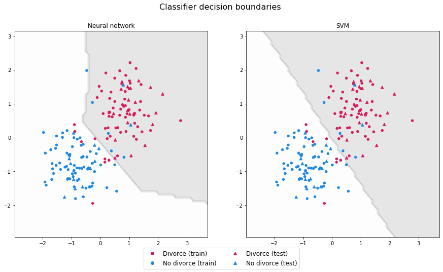

Additionally, testing accuracies for the two-feature classifiers (including classifiers trained using different parameter values) are below, with the plotted classifiers in **bold**:

| Classifier | Testing Accuracy (Divorce) |
| --- | --- |
| **Neural network (step size=0.1)** | **94.1%** |
| Neural network (step size=0.01) | 94.1% |
| Neural network (step size=0.001) | 88.2% |
| **SVM (C=1.0)** | **94.1%** |
| SVM (C=0.1) | 94.1% |
| SVM (C=0.01) | 94.1% |

My observations:

## Part 2: Handwritten digits classification

Repeat the above part (a) using the **MNIST data** in our previous homework. Here, give "digit" 6 label $y=1$ and give "digit" 2 label $y=0$. All of the pixels in each image will be the feature (predictor) variables for that sample (i.e. image). Our goal is to build classifiers such that given a new testing sample, we can tell it is a 2 or a 6. Use the first 80% of the samples for training and remaining 20% for testing.

Report the classification accuracy on testing data for each of the two classifiers. Comment on their performance: which performs better and make a guess why they perform better in this setting.

| Classifier | Testing Accuracy (Divorce) |
| --- | --- |
| **Neural network (step size=0.1)** | **98.2%** |
| Neural network (step size=0.01 | 97.7% |
| Neural network (step size=0.001) | 98.2% |
| **SVM (C=1.0)** | **98.7%** |
| SVM (C=0.1) | 98.5% |
| SVM (C=0.01) | 97.7% |

# 3. AdaBoost

Consider the following dataset, plotting in Figure 1. The first two coordinates represent the value of two features, and the last coordinate is the binary label of the data.

$$\begin{align} X_1&=(-1,0,+)\\ X_2&=(-0.5,0.5,+)\\ X_3&=(0,1,-)\\ X_4&=(0.5,1,-)\\ X_5&=(1,0,+)\\ X_6&=(1,-1,+)\\ X_7&=(0,-1,-)\\ X_8&=(0,0,-) \end{align}$$

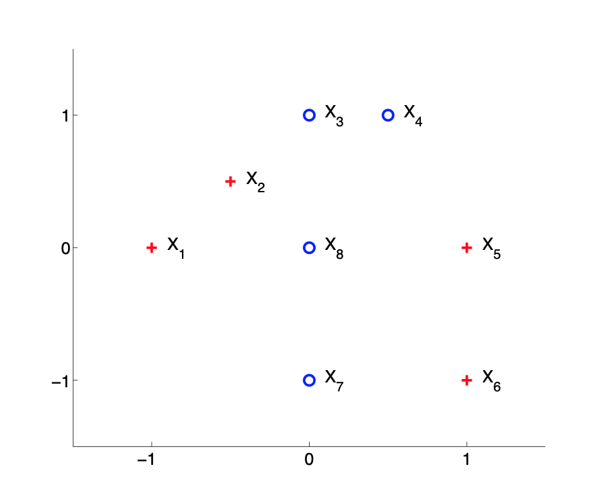

In this problem, you will run through $T=3$ iterations of AdaBoost with decision stumps (axis-aligned half planes) as weak learners.

## a. Iteration results

For each iteration $t=1,2,3$, compute $\epsilon_t$, $\alpha_t$, $Z_t$, and $D_t$ by hand (i.e. show all the calculation steps) and draw the decision stumps on Figure 1. Recall that $Z_t$ is the normalization factor to ensure that the weights $D_t$ sum to one. *(Hint: at each iteration, you may specify any reasonable decision rule $h_t$ as you would like.)*

The final table of $\epsilon_t$, $\alpha_t$, $Z_t$, and $D_t(i)$ values is shown below. An Excel spreadsheet (`q3_calculations.xlsx`) is also included showing non-truncated values.

| $t$ | $\epsilon_t$ | $\alpha_t$ | $Z_t$ | $D_t(1)$ | $D_t(2)$ | $D_t(3)$ | $D_t(4)$ | $D_t(5)$ | $D_t(6)$ | $D_t(7)$ | $D_t(8)$ |
| --- | --- | --- | --- | --- | --- | --- | --- | --- | --- | --- | --- |
| 1 | 0.2500 | 0.5493 | 0.8660 | 0.1250 | 0.1250 | 0.1250 | 0.1250 | 0.1250 | 0.1250 | 0.1250 | 0.1250 |
| 2 | 0.1667 | 0.8047 | 0.7454 | 0.2500 | 0.2500 | 0.0833 | 0.0833 | 0.0833 | 0.0833 | 0.0833 | 0.0833 |
| 3 | 0.1000 | 1.0986 | 0.6000 | 0.1500 | 0.1500 | 0.0500 | 0.0500 | 0.2500 | 0.2500 | 0.0500 | 0.0500 |

### i. Iteration 1

- The decision rule $h_1$ is indicated by the black line
- Points in the red-shaded area are classified $+$; points in the blue area are classified $-$
- Misclassified points are circled in dark red; in iteration 1, these are $x_1$ and $x_2$

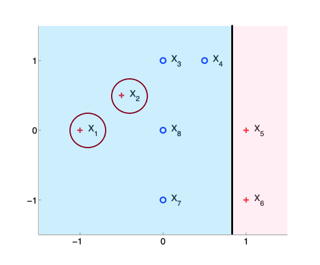

For the first iteration, $D_1(i)$ is initialized as $1/8 = 0.125$ for all points $i$. The table below shows the calculations for each data point:

| $i$ | $D_1(i)$ | Misclassification Indicator | Individual Weighted Error |
| --- | --- | --- | --- |
| 1 | 0.1250 | 1 | 0.1250 $\cdot$ 1 = 0.1250 |
| 2 | 0.1250 | 1 | 0.1250 $\cdot$ 1 = 0.1250 |
| 3 | 0.1250 | 0 | 0.1250 $\cdot$ 0 = 0 |
| 4 | 0.1250 | 0 | 0.1250 $\cdot$ 0 = 0 |
| 5 | 0.1250 | 0 | 0.1250 $\cdot$ 0 = 0 |
| 6 | 0.1250 | 0 | 0.1250 $\cdot$ 0 = 0 |
| 7 | 0.1250 | 0 | 0.1250 $\cdot$ 0 = 0 |
| 8 | 0.1250 | 0 | 0.1250 $\cdot$ 0 = 0 |

- $\epsilon_1 = 0.125 + 0.125 = 0.25$, the sum of individual weighted errors.
- $\alpha_1 = \frac{1}{2}ln\left(\frac{1-\epsilon_1}{\epsilon_1}\right) = 0.5 \cdot ln\left(\frac{0.75}{0.25}\right) = 0.54931$
- $Z_1 = \sum_{i=1}^{m} D_t^{(i)} exp(-\alpha y_i h_1(x_i)) = 2(0.125 \cdot exp(0.54931)) + 6(0.125 \cdot exp(-0.54931)) = 0.86603$, the sum of all data point weights $D_1(i)$, boosted or damped based on misclassification in iteration 1

### ii. Iteration 2

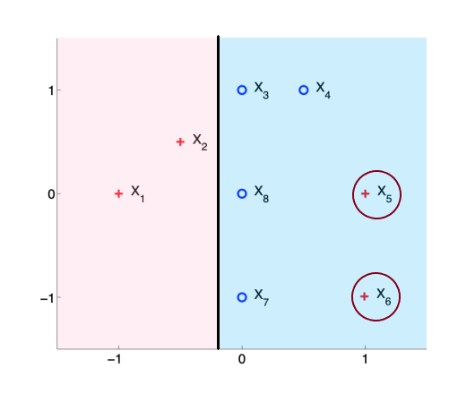

In iteration 2, points $x_5$ and $x_6$ are misclassified.

First, I calculate the weights $D_2(i) = \frac{D_1(i) exp(-\alpha_1 y_i h_1(x_i))}{Z_1}$, then use those to calculate the rest. The table below shows the weight calculations for each data point:

| $i$ | Misclassification Indicator (Iteration 1) | New Weight $D_2(i)$ |
| --- | --- | --- |
| 1 | 1 | 0.1250 $\cdot$ exp(0.54931) / 0.86603 = 0.2500 |
| 2 | 1 | 0.1250 $\cdot$ exp(0.54931) / 0.86603 = 0.2500 |
| 3 | 0 | 0.1250 $\cdot$ exp(-0.54931) / 0.86603 = 0.0833 |
| 4 | 0 | 0.1250 $\cdot$ exp(-0.54931) / 0.86603 = 0.0833 |
| 5 | 0 | 0.1250 $\cdot$ exp(-0.54931) / 0.86603 = 0.0833 |
| 6 | 0 | 0.1250 $\cdot$ exp(-0.54931) / 0.86603 = 0.0833 |
| 7 | 0 | 0.1250 $\cdot$ exp(-0.54931) / 0.86603 = 0.0833 |
| 8 | 0 | 0.1250 $\cdot$ exp(-0.54931) / 0.86603 = 0.0833 |

The table below shows the remaining calculations for each data point:

| $i$ | $D_2(i)$ | Misclassification Indicator | Individual Weighted Error |
| --- | --- | --- | --- |
| 1 | 0.2500 | 0 | 0.2500 $\cdot$ 0 = 0 |
| 2 | 0.2500 | 0 | 0.2500 $\cdot$ 0 = 0 |
| 3 | 0.0833 | 0 | 0.0833 $\cdot$ 0 = 0 |
| 4 | 0.0833 | 0 | 0.0833 $\cdot$ 0 = 0 |
| 5 | 0.0833 | 1 | 0.0833 $\cdot$ 1 = 0.0833 |
| 6 | 0.0833 | 1 | 0.0833 $\cdot$ 1 = 0.0833 |
| 7 | 0.0833 | 0 | 0.0833 $\cdot$ 0 = 0 |
| 8 | 0.0833 | 0 | 0.0833 $\cdot$ 0 = 0 |

- $\epsilon_2 = 0.0833 + 0.0833 = 0.1667$
- $\alpha_2 = \frac{1}{2}ln\left(\frac{1-\epsilon_2}{\epsilon_2}\right) = 0.5 \cdot ln\left(\frac{0.8333}{0.1667}\right) = 0.80472$
- $Z_2 = 2(0.2500 \cdot exp(-0.80472)) + 4(0.0833 \cdot exp(-0.80472)) + 2(0.0833 \cdot exp(0.80472)) = 0.74536$

### iii. Iteration 3

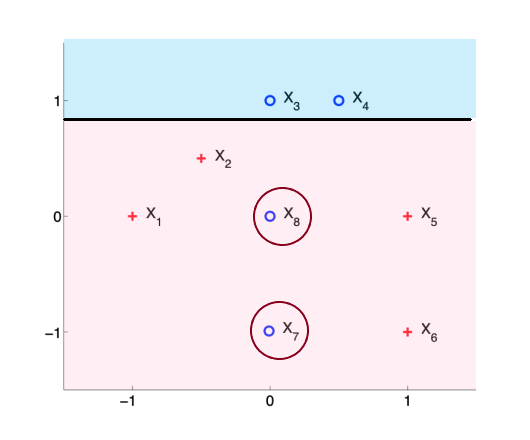

In iteration 3, points $x_7$ and $x_8$ are misclassified.

First, I calculate the weights $D_3(i) = \frac{D_2(i) exp(-\alpha_2 y_i h_2(x_i))}{Z_2} $, then use those to calculate the rest. The table below shows the weight calculations for each data point:

| $i$ | Misclassification Indicator (Iteration 2) | New Weight $D_3(i)$ |
| --- | --- | --- |
| 1 | 0 | 0.2500 $\cdot$ exp(-0.80472) / 0.74536 = 0.1500 |
| 2 | 0 | 0.2500 $\cdot$ exp(-0.80472) / 0.74536 = 0.1500 |
| 3 | 0 | 0.0833 $\cdot$ exp(-0.80472) / 0.74536 = 0.0500 |
| 4 | 0 | 0.0833 $\cdot$ exp(-0.80472) / 0.74536 = 0.0500 |
| 5 | 1 | 0.0833 $\cdot$ exp(0.80472) / 0.74536 = 0.2500 |
| 6 | 1 | 0.0833 $\cdot$ exp(0.80472) / 0.74536 = 0.2500 |
| 7 | 0 | 0.0833 $\cdot$ exp(-0.80472) / 0.74536 = 0.0500 |
| 8 | 0 | 0.0833 $\cdot$ exp(-0.80472) / 0.74536 = 0.0500 |

The table below shows the remaining calculations for each data point:

| $i$ | $D_3(i)$ | Misclassification Indicator | Individual Weighted Error |
| --- | --- | --- | --- |
| 1 | 0.1500 | 0 | 0.1500 $\cdot$ 0 = 0 |
| 2 | 0.1500 | 0 | 0.1500 $\cdot$ 0 = 0 |
| 3 | 0.0500 | 0 | 0.0500 $\cdot$ 0 = 0 |
| 4 | 0.0500 | 0 | 0.0500 $\cdot$ 0 = 0 |
| 5 | 0.2500 | 0 | 0.2500 $\cdot$ 0 = 0 |
| 6 | 0.2500 | 0 | 0.2500 $\cdot$ 0 = 0 |
| 7 | 0.0500 | 1 | 0.0500 $\cdot$ 1 = 0.0500 |
| 8 | 0.0500 | 1 | 0.0500 $\cdot$ 1 = 0.0500 |

- $\epsilon_3 = 0.05 + 0.05 = 0.1$
- $\alpha_3 = \frac{1}{2}ln\left(\frac{1-\epsilon_3}{\epsilon_3}\right) = 0.5 \cdot ln\left(\frac{0.9}{0.1}\right) = 1.09861$
- $Z_3 = 2(0.1500 \cdot exp(-1.09861)) + 2(0.0500 \cdot exp(-1.09861)) + 2(0.2500 \cdot exp(-1.09861)) + 2(0.0500 \cdot exp(1.09861)) = 0.6$

## b. Training error

What is the training error of AdaBoost? Give a one-sentence reason for why AdaBoost outperforms a single decision stump.

$h_{final}(x) = sign\left(\sum_t \alpha_t h_t(x)\right)$, the sign of the weighted combination (sum) of classifiers. The table below shows the calculations classifying each data point:

| $i$ | $\alpha_1 h_1(x_i)$ | $\alpha_2 h_2(x_i)$ | $\alpha_3 h_3(x_i)$ | Predicted Class | True Class $y_i$ |
| --- | --- | --- | --- | --- | --- |
| 1 | -0.54931 | 0.80472 | 1.09861 | $+$ | $+$ |
| 2 | -0.54931 | 0.80472 | 1.09861 | $+$ | $+$ |
| 3 | -0.54931 | -0.80472 | -1.09861 | $-$ | $-$ |
| 4 | -0.54931 | -0.80472 | -1.09861 | $-$ | $-$ |
| 5 | 0.54931 | -0.80472 | 1.09861 | $+$ | $+$ |
| 6 | 0.54931 | -0.80472 | 1.09861 | $+$ | $+$ |
| 7 | -0.54931 | -0.80472 | 1.09861 | $-$ | $-$ |
| 8 | -0.54931 | -0.80472 | 1.09861 | $-$ | $-$ |

For **all** data points used to train the model, the predicted class is the same as the true class. Therefore, the training error is **0%**.

AdaBoost outperforms a single decision stump because using multiple weak classifiers allows the model to classify the data from multiple "perspectives" instead of using only a single rule for classification.